# An Introduction to Statistical Learning (2013)

Solutions to Applied Exercises

by Brian Hassett

# Chapter 5 Resampling Methods

This notebook is a rough outline of solutions to the applied exercises in Chapter 5 of **An Introduction to Statistical Learning** (James et al. (2013)[^1]).

## Setup

```r
library(ISLR)
library(MASS)
library(tidyverse)
library(patchwork)
library(boot)
theme_set(theme_bw())

# Given a filename, return the filepath. Default folder is the `data` folder in the current working directory.
get_path <- function(filename) {
  str_c(getwd(), "data", filename, sep = "/")
}

# Colors:
ISLR_blue <- "#176FC0"
ISLR_brown <- "#94340E"
islr_lightblue <- "#68A5DB"
islr_orange <- "#CC5318"

# Return vector of the names of numeric columns in a data frame:
numeric_cols <- function(df) {
  is_numeric_cols <- map_lgl(df, is.numeric)
  return(names(df)[is_numeric_cols])
}

# Print accuracy, test rate and table of predicted labels and true labels:
test_rates <- function(predicted_label, test_label) {
  print(table(predicted_label, test_label))
  test_accuracy <- mean(predicted_label == test_label)*100
  test_error <- mean(predicted_label != test_label)*100
  print(str_interp("Test accuracy: ${round(test_accuracy, 2)}"))
  print(str_interp("Test error rate: ${round(test_error, 2)}"))
}
```

## Exercise 5

View data:

```r
Default
```

| default | student | balance | income |
| --- | --- | --- | --- |
| No | No | 729.5264952 | 44361.625 |
| No | Yes | 817.1804066 | 12106.135 |
| No | No | 1073.5491640 | 31767.139 |
| No | No | 529.2506047 | 35704.494 |
| No | No | 785.6558829 | 38463.496 |
| No | Yes | 919.5885305 | 7491.559 |
| No | No | 825.5133305 | 24905.227 |
| No | Yes | 808.6675043 | 17600.451 |
| No | No | 1161.0578540 | 37468.529 |
| No | No | 0.0000000 | 29275.268 |

[output cut: 990 more lines]

### (a)

Fit a logistic regression model that uses `income` and `balance` to predict `default` (use all of the data for now):

```r
mod1 <- glm(default ~ income + balance, data = Default, family = binomial)
summary(mod1)
```

```
Call:
glm(formula = default ~ income + balance, family = binomial,
    data = Default)

Deviance Residuals:
    Min       1Q   Median       3Q      Max
-2.4725  -0.1444  -0.0574  -0.0211   3.7245

Coefficients:
              Estimate Std. Error z value Pr(>|z|)
(Intercept) -1.154e+01  4.348e-01 -26.545  < 2e-16 ***
income       2.081e-05  4.985e-06   4.174 2.99e-05 ***
balance      5.647e-03  2.274e-04  24.836  < 2e-16 ***
---
Signif. codes:  0 ‘***’ 0.001 ‘**’ 0.01 ‘*’ 0.05 ‘.’ 0.1 ‘ ’ 1

(Dispersion parameter for binomial family taken to be 1)

    Null deviance: 2920.6  on 9999  degrees of freedom
Residual deviance: 1579.0  on 9997  degrees of freedom
AIC: 1585

Number of Fisher Scoring iterations: 8
```

### (b)

Split the data into a training and test set and fit a logistic regression model:

```r
set.seed(1)
train <- sample(nrow(Default), nrow(Default)/2)
mod2 <- glm(default ~ income + balance, data = Default, subset = train, family = binomial)
mod2_probs <- predict(mod2, newdata = Default[-train, ], type = "response")
mod2_preds <- rep("No", length(mod2_probs))
mod2_preds[mod2_probs > 0.5] <- "Yes"
test_rates(mod2_preds, Default$default[-train])
```

```
               test_label
predicted_label   No  Yes
            No  4824  108
            Yes   19   49
[1] "Test accuracy: 97.46"
[1] "Test error rate: 2.54"
```

### (c)

Repeat the process of fitting and evaluating model three times using three different seeds:

```r
set.seed(2)
train <- sample(nrow(Default), nrow(Default)/2)
mod2 <- glm(default ~ income + balance, data = Default, subset = train, family = binomial)
mod2_probs <- predict(mod2, newdata = Default[-train, ], type = "response")
mod2_preds <- rep("No", length(mod2_probs))
mod2_preds[mod2_probs > 0.5] <- "Yes"
test_rates(mod2_preds, Default$default[-train])
```

```
               test_label
predicted_label   No  Yes
            No  4819  101
            Yes   18   62
[1] "Test accuracy: 97.62"
[1] "Test error rate: 2.38"
```

```r
set.seed(3)
train <- sample(nrow(Default), nrow(Default)/2)
mod3 <- glm(default ~ income + balance, data = Default, subset = train, family = binomial)
mod3_probs <- predict(mod3, newdata = Default[-train, ], type = "response")
mod3_preds <- rep("No", length(mod3_probs))
mod3_preds[mod3_probs > 0.5] <- "Yes"
test_rates(mod3_preds, Default$default[-train])
```

```
               test_label
predicted_label   No  Yes
            No  4822  109
            Yes   23   46
[1] "Test accuracy: 97.36"
[1] "Test error rate: 2.64"
```

```r
set.seed(4)
train <- sample(nrow(Default), nrow(Default)/2)
mod4 <- glm(default ~ income + balance, data = Default, subset = train, family = binomial)
mod4_probs <- predict(mod4, newdata = Default[-train, ], type = "response")
mod4_preds <- rep("No", length(mod4_probs))
mod4_preds[mod4_probs > 0.5] <- "Yes"
test_rates(mod4_preds, Default$default[-train])
```

```
               test_label
predicted_label   No  Yes
            No  4815  107
            Yes   21   57
[1] "Test accuracy: 97.44"
[1] "Test error rate: 2.56"
```

Even though the training/test splits are different we get a similar accuracy rate.

### (d)

Fit a logistic regression model that predicts the probability of `default` using `income`, `balance` , and a dummy variable for `student`:

```r
set.seed(1)
train <- sample(nrow(Default), nrow(Default)/2)
mod5 <- glm(default ~ income + balance + student, data = Default, subset = train, family = binomial)
mod5_probs <- predict(mod5, newdata = Default[-train, ], type = "response")
mod5_preds <- rep("No", length(mod5_probs))
mod5_preds[mod5_probs > 0.5] <- "Yes"
test_rates(mod5_preds, Default$default[-train])
```

```
               test_label
predicted_label   No  Yes
            No  4825  112
            Yes   18   45
[1] "Test accuracy: 97.4"
[1] "Test error rate: 2.6"
```

The test error actually went up a small amount, 2.6% for this model versus 2.54% for the model which didn’t include `student`.

## Exercise 6

### (a)

Fit a logistic regression model that uses `income` and `balance` to predict `default` (use all of the data for now):

```r
mod1 <- glm(default ~ income + balance, data = Default, family = binomial)
summary(mod1)$coef
```

```
                 Estimate   Std. Error    z value      Pr(>|z|)
(Intercept) -1.154047e+01 4.347564e-01 -26.544680 2.958355e-155
income       2.080898e-05 4.985167e-06   4.174178  2.990638e-05
balance      5.647103e-03 2.273731e-04  24.836280 3.638120e-136
```

### (b)

```r
boot.fn <- function(data, index) {
  mod1 <- glm(default ~ income + balance, data = Default, subset = index, family = binomial)
  return(coef(mod1)[2:3])
}
boot.fn(Default, 1:nrow(Default))
```

```
      income      balance
2.080898e-05 5.647103e-03
```

### (c)

```r
boot(Default, boot.fn, 1000)
```

```
ORDINARY NONPARAMETRIC BOOTSTRAP


Call:
boot(data = Default, statistic = boot.fn, R = 1000)


Bootstrap Statistics :
        original       bias     std. error
t1* 2.080898e-05 1.585717e-07 4.858722e-06
t2* 5.647103e-03 1.856917e-05 2.300758e-04
```

### (d)

The standard errors calculated using `glm()` and the `suumary()` function are very close to those calculated using the bootstrap method.

## Exercise 7

### (a)

Fit a logistic regression model that predicts `Direction` using `Lag1` and `Lag2`:

```r
mod1 <- glm(Direction ~ Lag1 + Lag2, data = Weekly, family = binomial)
summary(mod1)
```

```
Call:
glm(formula = Direction ~ Lag1 + Lag2, family = binomial, data = Weekly)

Deviance Residuals:
   Min      1Q  Median      3Q     Max
-1.623  -1.261   1.001   1.083   1.506

Coefficients:
            Estimate Std. Error z value Pr(>|z|)
(Intercept)  0.22122    0.06147   3.599 0.000319 ***
Lag1        -0.03872    0.02622  -1.477 0.139672
Lag2         0.06025    0.02655   2.270 0.023232 *
---
Signif. codes:  0 ‘***’ 0.001 ‘**’ 0.01 ‘*’ 0.05 ‘.’ 0.1 ‘ ’ 1

(Dispersion parameter for binomial family taken to be 1)

    Null deviance: 1496.2  on 1088  degrees of freedom
Residual deviance: 1488.2  on 1086  degrees of freedom
AIC: 1494.2

Number of Fisher Scoring iterations: 4
```

### (b)

Fit a logistic regression model that predicts `Direction` using `Lag1` and `Lag2` using *all but the first observation*.

```r
n <- nrow(Weekly)
mod2 <- glm(Direction ~ Lag1 + Lag2, data = Weekly, family = binomial, subset = 2:n)
summary(mod2)
```

```
Call:
glm(formula = Direction ~ Lag1 + Lag2, family = binomial, data = Weekly,
    subset = 2:n)

Deviance Residuals:
    Min       1Q   Median       3Q      Max
-1.6258  -1.2617   0.9999   1.0819   1.5071

Coefficients:
            Estimate Std. Error z value Pr(>|z|)
(Intercept)  0.22324    0.06150   3.630 0.000283 ***
Lag1        -0.03843    0.02622  -1.466 0.142683
Lag2         0.06085    0.02656   2.291 0.021971 *
---
Signif. codes:  0 ‘***’ 0.001 ‘**’ 0.01 ‘*’ 0.05 ‘.’ 0.1 ‘ ’ 1

(Dispersion parameter for binomial family taken to be 1)

    Null deviance: 1494.6  on 1087  degrees of freedom
Residual deviance: 1486.5  on 1085  degrees of freedom
AIC: 1492.5

Number of Fisher Scoring iterations: 4
```

### (c)

Make a prediction for the first observation using the model from part (b):

```r
mod2_prob <- predict(mod2, newdata = Weekly[1, ], type = "response")
mod2_pred <- ifelse(mod2_prob > 0.5, "Up", "Down")
mod2_pred
```

```
   1
"Up"
```

```r
Weekly$Direction[1]
```

```
[1] Down
Levels: Down Up
```

The observation was not correctly classified.

### (d)

Use a for loop to implement LOOCV:

```r
errors <- rep(NA, n)

for(i in 1:n) {
  mod <- glm(Direction ~ Lag1 + Lag2, data = Weekly, family = binomial, subset = -i)
  prob <- predict(mod, newdata = Weekly[i, ], type = "response")
  pred <- ifelse(prob > 0.5, "Up", "Down")
  errors[i] <- ifelse(Weekly$Direction[i] == pred, 0, 1)
}
```

### (e)

Calculate the LOOCV estimate for the test error:

```r
mean(errors)
```

```
[1] 0.4499541
```

## Exercise 8

### (a)

Generate a simulated data set:

```r
set.seed(1)
x <- rnorm(100)
y <- x - 2*x^2 + rnorm(100)
```

Since there are 100 data points, $n = 100$. There is only one feature, $x$, therefore $p = 1$.

The model is $Y=X-2X^2+\epsilon$.

### (b)

Plot the data:

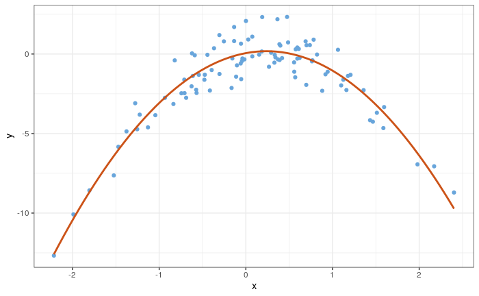

```r
data.frame(x, y) %>%
  ggplot(aes(x, y)) +
  geom_point(color = islr_lightblue) +
  geom_smooth(method = "lm", formula = y ~ poly(x, 2), # add a quadratic fit to the plot
              se = FALSE, color = islr_orange)
```

There is an obvious non-linear (quadratic) relationship between the variables.

### (c)

Calculate the LOOCV errors that result from fitting the following four models:
$$Y = \beta_0 + \beta_1X + \epsilon$$
$$Y = \beta_0 + \beta_1 X+ \beta_2X^2 + \epsilon$$
$$Y = \beta_0 + \beta_1X + \beta_2X^2 + \beta_3X^3 + \epsilon$$
$$Y = \beta_0 + \beta_1X + \beta_2X^2 + \beta_3X^3 + \beta_4X^4 + \epsilon$$

```r
df <- data.frame(x, y)

set.seed(1)
d <- 4
cv_error <- rep(0, d)
for(i in 1:d) {
  mod <- glm(y ~ poly(x, i), data = df)
  cv_mod <- cv.glm(df, mod)
  cv_error[i] <- cv_mod$delta[1]
}

cv_error
```

```
[1] 7.2881616 0.9374236 0.9566218 0.9539049
```

There is a dramatic reduction in LOOCV error when the quadratic term is included, however the additional cubic and quartic terms actually cause the error to rise slightly.

### (d)

```r
set.seed(2)
d <- 4
cv_error <- rep(0, d)
for(i in 1:d) {
  mod <- glm(y ~ poly(x, i), data = df)
  cv_mod <- cv.glm(df, mod)
  cv_error[i] <- cv_mod$delta[1]
}

cv_error
```

```
[1] 7.2881616 0.9374236 0.9566218 0.9539049
```

Yes, the results are the same. This is due to the fact that LOOCV does not randomly sample the data to form training and test sets. Rather, it goes through the whole data set and produces $n$ training sets of size $n-1$, and $n$ corresponding test sets of size $1$. These sets will be the same regardless of any seed.

### (e)

The model which included the quadratic term, $Y=\beta_{0}+\beta_{1} X+\beta_{2} X^{2}+\epsilon$, had the smallest LOOCV error. This is to be expected as the data was generated using a model which fits this form, $Y=X-2X^2+\epsilon$. In the true model the coefficients are: $\beta_{0}=0; \beta_{1}=1; \beta_{2}=-2$.

### (f)

```r
map(1:d, function(d) {
  mod <- lm(y ~ poly(x, d), data = df)
  return(summary(mod)$coef)
})
```

```
[[1]]
             Estimate Std. Error   t value     Pr(>|t|)
(Intercept) -1.550023  0.2600138 -5.961308 3.953542e-08
poly(x, d)   6.188826  2.6001382  2.380191 1.923846e-02

[[2]]
              Estimate Std. Error    t value     Pr(>|t|)
(Intercept)  -1.550023 0.09580323 -16.179231 2.656229e-29
poly(x, d)1   6.188826 0.95803228   6.459934 4.184810e-09
poly(x, d)2 -23.948305 0.95803228 -24.997388 4.584330e-44

[[3]]
               Estimate Std. Error    t value     Pr(>|t|)
(Intercept)  -1.5500226 0.09626318 -16.101926 4.995066e-29
poly(x, d)1   6.1888256 0.96263178   6.429068 4.971565e-09
poly(x, d)2 -23.9483049 0.96263178 -24.877950 1.216703e-43
poly(x, d)3   0.2641057 0.96263178   0.274358 7.843990e-01

[[4]]
               Estimate Std. Error     t value     Pr(>|t|)
(Intercept)  -1.5500226 0.09590514 -16.1620379 5.169227e-29
poly(x, d)1   6.1888256 0.95905143   6.4530695 4.590732e-09
poly(x, d)2 -23.9483049 0.95905143 -24.9708243 1.593826e-43
poly(x, d)3   0.2641057 0.95905143   0.2753822 7.836207e-01
poly(x, d)4   1.2570950 0.95905143   1.3107691 1.930956e-01
```

## Exercise 9

### (a)

Provide an estimate for the population mean of `medv`:

```r
medv.bar <- mean(Boston$medv)
medv.bar
```

```
[1] 22.53281
```

$\bar{\mu} = 22.53281$

### (b)

Provide an estimate of the standard error of $\bar{\mu}$:

```r
n <- nrow(Boston)
sd(Boston$medv)/sqrt(n)
```

```
[1] 0.4088611
```

$\text{SE}(\hat{\mu})=0.4088611$

### (c)

Now estimate the standard error of $\bar{\mu}$ using the bootstrap:

```r
library(boot)
set.seed(1)

sample.mean <- function(x, i) {
  mean(x[i])
}
boot.result <- boot(Boston$medv, sample.mean, R=1000)
boot.result
```

```
ORDINARY NONPARAMETRIC BOOTSTRAP


Call:
boot(data = Boston$medv, statistic = sample.mean, R = 1000)


Bootstrap Statistics :
    original      bias    std. error
t1* 22.53281 0.007650791   0.4106622
```

The bootstrap estimate of $\text{SE}(\hat{\mu})$ is close to that found in part (b).

### (d)

Calculate a 95% confidence interval for $\bar{\mu}$:

```r
mu.hat <- boot.result$t0
SE.mu.hat <- sd(boot.result$t)
ci.lower <- round(mu.hat - 2*SE.mu.hat, 2)
ci.upper <- round(mu.hat + 2*SE.mu.hat, 2)
str_interp("The 95% CI is (${ci.lower}, ${ci.upper})")
```

```
[1] "The 95% CI is (21.71, 23.35)"
```

Using t-test to calculate the interval:

```r
t.test(Boston$medv)
```

```
    One Sample t-test

data:  Boston$medv
t = 55.111, df = 505, p-value < 2.2e-16
alternative hypothesis: true mean is not equal to 0
95 percent confidence interval:
 21.72953 23.33608
sample estimates:
mean of x
 22.53281
```

The 95% confidence interval found using the bootstrap estimate is similar to that found using the t-test:

- Lower bounds: 21.71 vs 21.73
- Upper bounds: 23.35 vs 23.34

### (e)

Provide an estimate for the population median of `medv`:

```r
median(Boston$medv)
```

```
[1] 21.2
```

### (f)

```r
library(boot)
set.seed(1)

sample.median <- function(x, i) {
  median(x[i])
}
boot.result <- boot(Boston$medv, sample.median, R = 1000)
boot.result
```

```
ORDINARY NONPARAMETRIC BOOTSTRAP


Call:
boot(data = Boston$medv, statistic = sample.median, R = 1000)


Bootstrap Statistics :
    original  bias    std. error
t1*     21.2 0.02295   0.3778075
```

### (g)

Calculate an estimate for the tenth percentile of `medv`. Call this quantity $\hat{\mu}_{0.1}$.

```r
quantile(Boston$medv, 0.1)
```

```
  10%
12.75
```

### (h)

Use the bootstrap to estimate the standard error of $\hat{\mu}_{0.1}$.

```r
library(boot)
set.seed(1)

boot.fn <- function(x, i) {
  quantile(x[i], 0.1)
}
boot.result <- boot(Boston$medv, boot.fn, R=1000)
boot.result
```

```
ORDINARY NONPARAMETRIC BOOTSTRAP


Call:
boot(data = Boston$medv, statistic = boot.fn, R = 1000)


Bootstrap Statistics :
    original  bias    std. error
t1*    12.75  0.0339   0.4767526
```

[^1]: James G, Witten D, Hastie T, Tibshirani R (2013). *An Introduction to Statistical Learning: with Applications in R*. Springer, 1st edition.